# Evaluation of the effects of changes in Smax and Srep on the shape of the Ricker recruitment curve

# 1 The ricker curve

For the purpose of this demonstration we will assume that the salmon populations follow the deterministic Ricker curve withe the following specification.

$R_t = a*S_t*exp(-b*S_t)$

$S_{max} = \frac{1}{b}$

$S_{rep} = \frac{log(a)}{b}$

Where

$R_t$ is the recruitment for brood year t $S_t$ is the spawners for brood year t $a$ is the productivity parameter (slope near the origin) $b$ is the inverse of the capacity parameter $S_{max}$ is the spawners that maximize recruits (spawners at the peak of the curve) $S_{rep}$ is the spawners at replacement, x spawners will produce x recruits

In the following sections we will investigate the effects of assuming time varying $a$ and $b$ and keeping $Srep$ constant or allowing it to vary.

# 2 Capacity changes

First we evaluate the scenario in which $b$ changes and Srep is allowed to vary according to the equations in the previous sections. When $Srep$ varies, the $a$ parameter is kept constant and $Srep$ increases as $Smax$ increases. In this scenario, higher values of $Smax$/$Srep$ lead to higher recruitment at the same $S_t$ values (see left panel on Figure 2.1).

When looking at the effects on the estimates of $Smsy$, we see that Smsy increases linearly with $Smax$ when $Srep$ varies , but increases asymptotically when $Srep$ is kept constant (and productivity varies) (Figure 2.2). $Sgen$ tends to increase linearly when Smax increases, but the increase has higher slope in the scenario where $Srep$is kept constant (Figure 2.2).

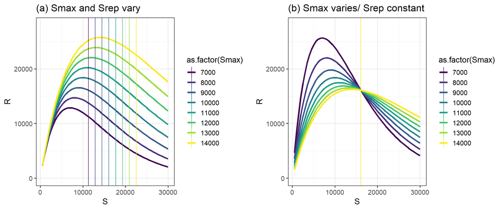

Figure 2.1: Potential shapes of the Ricker curve when b varies and Srep varies (left) or is kept constant (right). Vertical lines indicate Srep values.

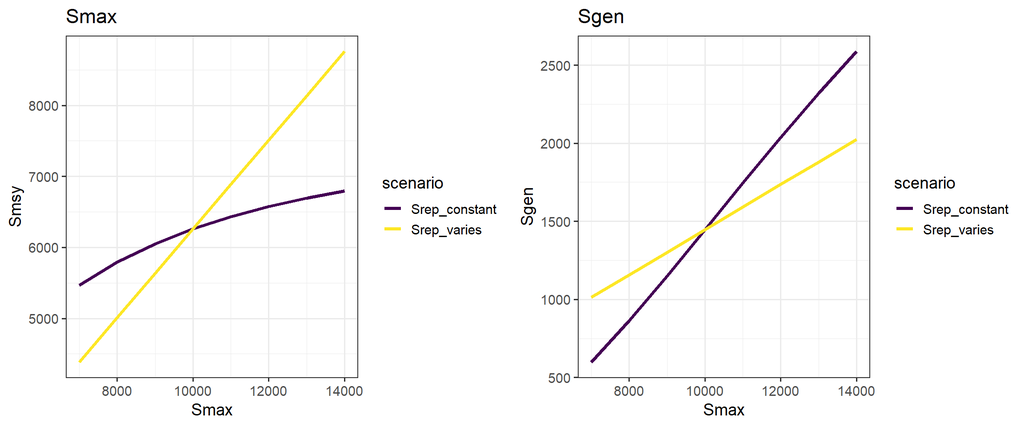

Figure 2.2: Increases in Smsy i relation to Smax when Srep varies or is kept constant.

# 3 Productivity changes

In the scenarios when the productivity parameters are driving change, a similar exercise can be done. In this case the choice between $Smax$ and $Srep$ being fixed depends on biological mechanism: whether we think that recruitment is reduced at most levels of spawner abundances ($Smax$ if fixed) or we think the spawner abundance where density dependence result in over compensation starts at a lower spawner abundance ($Srep$ is fixed).

In the first scenario, productivity ($a$) changes and $Smax$ is kept constant, higher productivities lead to higher recruitment at all levels of spawner abundances (see left panel on Figure 3.1). The $Srep$ value increases as productivity increases.

In the second scenario, productivity ($a$) changes and $Srep$ is kept constant, therefore $Smax$ is allowed to vary. In this case lower productivities will have higher $Smax$ (inverse relation) (see right panel on Figure 3.1).

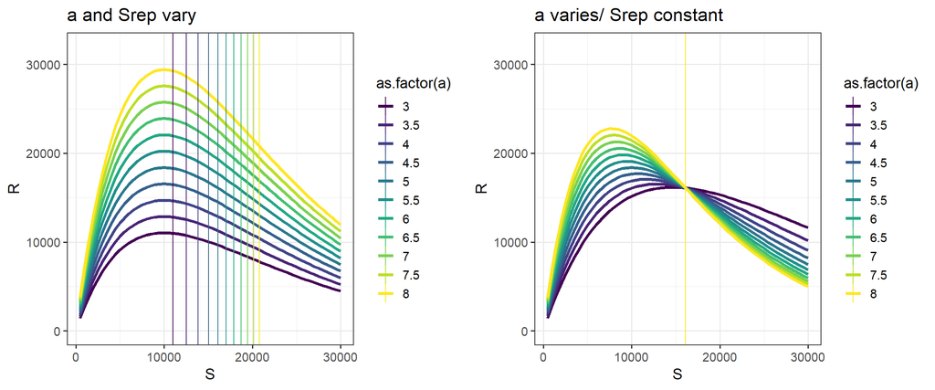

Figure 3.1: Potential shapes of the Ricker curve when a varies and Srep varies (left) or is kept constant. Vertical lines indicate Srep values.

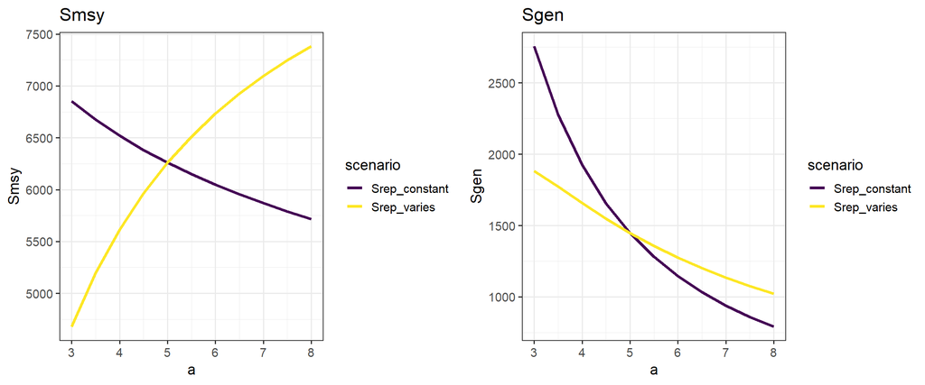